# Analyse en Composantes Principales (ACP) sur les données de yaourts

QURESHI Hamza

# Introduction

Un hypermarché de la région a enquêté auprès de 25 clients pour comparer trois marques de yaourt “nature” appelées a, b, et c. Les clients ont donné des notes sur l’échelle de 1 à 5 pour différents critères : le goût, l’aspect et le prix des produits.

L’objectif est d’utiliser l’Analyse en Composantes Principales (ACP) pour estimer les grandes tendances du goût des clients et faire des sous-groupes pour améliorer le chiffre d’affaires.

# Exercice 1

## 1) Sur quels types de données s’appliquer l’ACP ?

L’ACP est une méthode statistique qui s’applique aux données numériques continues. Dans ce cas, l’ACP s’applique aux variables numériques Ga, Gb, Gc, Aa, Ab, Ac, Pa, Pb, Pc, qui correspondent aux notes sur une échelle de 1 à 5 données par les clients pour le goût, l’aspect et le prix des marques de yaourt.

## 2) Quelle est la différence entre une ACP normée et une ACP non normée ?

Dans une ACP normée, on centre et réduit les données (soustraction de la moyenne et division par l’écart-type) avant de procéder à l’ACP. Cela permet de comparer des variables ayant des unités ou des échelles différentes (par exemple, des notes sur des échelles de 1 à 5 et 1 à 10). Tandis que dans une ACP non normée, on effectue l’ACP sur les données brutes, sans modification d’échelle. Cela peut biaiser l’analyse si les variables ont des unités ou des échelles différentes.

## 3) Comment détermine-t-on la contribution d’une ligne et d’une colonne (variable) en ACP normée ?

La contribution d’une ligne est liée à la projection de chaque observation (client) dans le nouvel espace des composantes principales. La contribution d’une colonne (variable) mesure l’importance relative de chaque variable dans les nouvelles composantes principales.

## 4) Décrire les différentes étapes d’une ACP normée.

Les étapes d’une ACP normée sont :

1. La standardisation des données : Centrer et réduire les variables (soustraction de la moyenne et division par l’écart-type).
2. Le calcul des composantes principales : Calculer les valeurs propres et les vecteurs propres pour décomposer les données dans un nouvel espace de dimension réduite.
3. La projection des données : Représenter les données dans cet espace de composantes principales.
4. L’interprétation des résultats : Analyser les scores et les contributions des variables pour comprendre les tendances principales.
5. La visualisation : Créer des graphiques comme le scree plot et le biplot pour faciliter l’interprétation des résultats.

# Exercice 2

```
##   Clients Ga Aa Pa Gb Ab Pb Gc Ac Pc
## 1    CL01  4  2  4  5  5  5  4  4  2
## 2    CL02  2  2  4  3  2  5  4  5  1
## 3    CL03  2  2  1  2  3  3  3  1  4
## 4    CL04  1  1  2  2  3  3  4  3  2
## 5    CL05  3  4  4  4  3  1  2  1  2
## 6    CL06  1  1  1  1  2  4  3  2  4
```

```
## 'data.frame':    25 obs. of  10 variables:
##  $ Clients: chr  "CL01" "CL02" "CL03" "CL04" ...
##  $ Ga     : int  4 2 2 1 3 1 4 2 4 2 ...
##  $ Aa     : int  2 2 2 1 4 1 4 3 5 2 ...
##  $ Pa     : int  4 4 1 2 4 1 2 3 1 5 ...
##  $ Gb     : int  5 3 2 2 4 1 2 3 3 1 ...
##  $ Ab     : int  5 2 3 3 3 2 2 4 3 1 ...
##  $ Pb     : int  5 5 3 3 1 4 1 3 2 3 ...
##  $ Gc     : int  4 4 3 4 2 3 2 1 4 2 ...
##  $ Ac     : int  4 5 1 3 1 2 1 1 2 3 ...
##  $ Pc     : int  2 1 4 2 2 4 3 1 4 3 ...
```

## 1) Quelle est la nature des données ?

Les données sont des données qualitatives ordinales, car les variables mesurent des évaluations données par des clients sur une échelle de 1 à 5 pour chaque critère (goût, aspect, et prix des yaourts).

Cependant même si ces variables sont ordinales (car il y a un ordre dans les notes), elles peuvent être traitées comme des données numériques continues pour effectuer une ACP, car les distances entre les valeurs (par exemple, entre 1 et 2, 2 et 3, etc.) sont considérées comme égales.

## 2) Quelles sont les variables dont les distributions sont les plus différentes ? Que peut-on dire du goût des yaourts ? De l’aspect ? Du prix ?

Pour répondre à cette question, nous devons examiner les distributions des différentes variables (Goût, Aspect, et Prix) et comparer les écarts-types, les moyennes, et les éventuelles différences entre les variables. Nous allons comparer ces variables en utilisant des statistiques descriptives, telles que les moyennes, les écarts-types, et des visualisations comme les boxplots.

```
##        Ga             Gb             Gc             Aa             Ab
##  Min.   :1.00   Min.   :1.00   Min.   :1.00   Min.   :1.00   Min.   :1.0
##  1st Qu.:2.00   1st Qu.:1.00   1st Qu.:2.00   1st Qu.:2.00   1st Qu.:2.0
##  Median :3.00   Median :2.00   Median :3.00   Median :3.00   Median :2.0
##  Mean   :2.64   Mean   :2.32   Mean   :2.72   Mean   :2.72   Mean   :2.6
##  3rd Qu.:4.00   3rd Qu.:3.00   3rd Qu.:4.00   3rd Qu.:4.00   3rd Qu.:3.0
##  Max.   :5.00   Max.   :5.00   Max.   :4.00   Max.   :5.00   Max.   :5.0
##        Ac             Pa             Pb            Pc
##  Min.   :1.00   Min.   :1.00   Min.   :1.0   Min.   :1.0
##  1st Qu.:1.00   1st Qu.:1.00   1st Qu.:2.0   1st Qu.:2.0
##  Median :2.00   Median :2.00   Median :3.0   Median :3.0
##  Mean   :2.28   Mean   :2.36   Mean   :2.8   Mean   :2.8
##  3rd Qu.:3.00   3rd Qu.:3.00   3rd Qu.:4.0   3rd Qu.:4.0
##  Max.   :5.00   Max.   :5.00   Max.   :5.0   Max.   :4.0
```

```
##        Ga        Gb        Gc        Aa        Ab        Ac        Pa        Pb
## 1.1860298 1.3140269 1.1372481 1.2423097 0.9574271 1.1733144 1.2543258 1.2909944
##        Pc
## 1.1902381
```

```
##   Ga   Gb   Gc   Aa   Ab   Ac   Pa   Pb   Pc
## 2.64 2.32 2.72 2.72 2.60 2.28 2.36 2.80 2.80
```

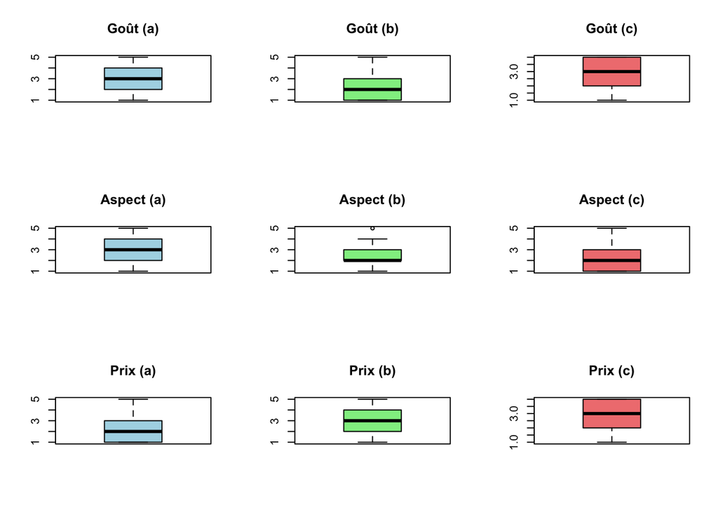

La variable prix est celle dont les distributions sont les plus différentes, avec des avis plus partagés sur le prix des différentes marques de yaourt.

Le Goût des yaourts est globalement perçu comme correct, avec des opinions relativement homogènes.

Et l’aspect des yaourts également perçu de manière assez uniforme, sans grandes différences entre les marques.

## 3) Quels sont les coefficients de corrélation linéaires les plus élevés? Les plus faibles ? Les plus proches de 0 ? En déduire la nature des relations entre les critères. Il conviendrait de faire des tests de significativité en posant convenablement les hypothèses.

```r
data_notes <- data_yaourt %>%
  select(Ga, Gb, Gc, Aa, Ab, Ac, Pa, Pb, Pc)

data_notes[] <- lapply(data_notes, function(x) as.numeric(as.character(x)))

# Calculer la matrice des corrélations entre toutes les variables
correlation <- rcorr(as.matrix(data_notes))
correlation$r
```

```
##             Ga         Gb          Gc          Aa          Ab          Ac
## Ga  1.00000000  0.3978248 -0.17052066  0.66398976 -0.02201601  0.01556977
## Gb  0.39782479  1.0000000  0.22975051 -0.01939850  0.66900622  0.26376668
## Gc -0.17052066  0.2297505  1.00000000 -0.41170778  0.16072265  0.52959634
## Aa  0.66398976 -0.0193985 -0.41170778  1.00000000 -0.02802484 -0.42992463
## Ab -0.02201601  0.6690062  0.16072265 -0.02802484  1.00000000 -0.08160022
## Ac  0.01556977  0.2637667  0.52959634 -0.42992463 -0.08160022  1.00000000
## Pa  0.17477020  0.6097495  0.01518891 -0.03957403  0.29838097  0.38163999
## Pb -0.48438288  0.2112315  0.44272469 -0.76380385  0.23596995  0.56115153
## Pc  0.06493547 -0.4901946  0.04925152  0.12962324 -0.43876345 -0.25658955
##             Pa         Pb          Pc
## Ga  0.17477020 -0.4843829  0.06493547
## Gb  0.60974948  0.2112315 -0.49019456
## Gc  0.01518891  0.4427247  0.04925152
## Aa -0.03957403 -0.7638039  0.12962324
## Ab  0.29838097  0.2359700 -0.43876345
## Ac  0.38163999  0.5611515 -0.25658955
## Pa  1.00000000  0.2264314 -0.59167117
## Pb  0.22643142  1.0000000 -0.29827938
## Pc -0.59167117 -0.2982794  1.00000000
```

```r
# Identifier les coefficients les plus élevés (en valeur absolue)
max_corr <- which(abs(correlation$r) == max(abs(correlation$r[correlation$r != 1])), arr.ind = TRUE)
print(max_corr)
```

```
##    row col
## Pb   8   4
## Aa   4   8
```

```r
# Identifier les coefficients les plus faibles (en valeur absolue)
min_corr <- which(abs(correlation$r) == min(abs(correlation$r[correlation$r != 1])), arr.ind = TRUE)
print(min_corr)
```

```
##    row col
## Pa   7   3
## Gc   3   7
```

```r
# Identifier les coefficients proches de 0 (moins de 0.1 en valeur absolue)
near_zero_corr <- which(abs(correlation$r) < 0.1 & correlation$r != 1, arr.ind = TRUE)
print(near_zero_corr)
```

```
##    row col
## Ab   5   1
## Ac   6   1
## Pc   9   1
## Aa   4   2
## Pa   7   3
## Pc   9   3
## Gb   2   4
## Ab   5   4
## Pa   7   4
## Ga   1   5
## Aa   4   5
## Ac   6   5
## Ga   1   6
## Ab   5   6
## Gc   3   7
## Aa   4   7
## Ga   1   9
## Gc   3   9
```

```
##             Ga         Gb          Gc          Aa          Ab          Ac
## Ga  1.00000000  0.3978248 -0.17052066  0.66398976 -0.02201601  0.01556977
## Gb  0.39782479  1.0000000  0.22975051 -0.01939850  0.66900622  0.26376668
## Gc -0.17052066  0.2297505  1.00000000 -0.41170778  0.16072265  0.52959634
## Aa  0.66398976 -0.0193985 -0.41170778  1.00000000 -0.02802484 -0.42992463
## Ab -0.02201601  0.6690062  0.16072265 -0.02802484  1.00000000 -0.08160022
## Ac  0.01556977  0.2637667  0.52959634 -0.42992463 -0.08160022  1.00000000
## Pa  0.17477020  0.6097495  0.01518891 -0.03957403  0.29838097  0.38163999
## Pb -0.48438288  0.2112315  0.44272469 -0.76380385  0.23596995  0.56115153
## Pc  0.06493547 -0.4901946  0.04925152  0.12962324 -0.43876345 -0.25658955
##             Pa         Pb          Pc
## Ga  0.17477020 -0.4843829  0.06493547
## Gb  0.60974948  0.2112315 -0.49019456
## Gc  0.01518891  0.4427247  0.04925152
## Aa -0.03957403 -0.7638039  0.12962324
## Ab  0.29838097  0.2359700 -0.43876345
## Ac  0.38163999  0.5611515 -0.25658955
## Pa  1.00000000  0.2264314 -0.59167117
## Pb  0.22643142  1.0000000 -0.29827938
## Pc -0.59167117 -0.2982794  1.00000000
```

```
## p-value pour la corrélation entre Ga et Gb : 0.0489 (Significatif)
## p-value pour la corrélation entre Ga et Gc : 0.4151 (Non significatif)
## p-value pour la corrélation entre Ga et Aa : 0.0003 (Significatif)
## p-value pour la corrélation entre Ga et Ab : 0.9168 (Non significatif)
## p-value pour la corrélation entre Ga et Ac : 0.9411 (Non significatif)
## p-value pour la corrélation entre Ga et Pa : 0.4034 (Non significatif)
## p-value pour la corrélation entre Ga et Pb : 0.0141 (Significatif)
## p-value pour la corrélation entre Ga et Pc : 0.7578 (Non significatif)
## p-value pour la corrélation entre Gb et Gc : 0.2692 (Non significatif)
## p-value pour la corrélation entre Gb et Aa : 0.9267 (Non significatif)
## p-value pour la corrélation entre Gb et Ab : 0.0003 (Significatif)
## p-value pour la corrélation entre Gb et Ac : 0.2027 (Non significatif)
## p-value pour la corrélation entre Gb et Pa : 0.0012 (Significatif)
## p-value pour la corrélation entre Gb et Pb : 0.3108 (Non significatif)
## p-value pour la corrélation entre Gb et Pc : 0.0129 (Significatif)
## p-value pour la corrélation entre Gc et Aa : 0.0409 (Significatif)
## p-value pour la corrélation entre Gc et Ab : 0.4428 (Non significatif)
## p-value pour la corrélation entre Gc et Ac : 0.0065 (Significatif)
## p-value pour la corrélation entre Gc et Pa : 0.9426 (Non significatif)
## p-value pour la corrélation entre Gc et Pb : 0.0267 (Significatif)
## p-value pour la corrélation entre Gc et Pc : 0.8151 (Non significatif)
## p-value pour la corrélation entre Aa et Ab : 0.8942 (Non significatif)
## p-value pour la corrélation entre Aa et Ac : 0.0320 (Significatif)
## p-value pour la corrélation entre Aa et Pa : 0.8510 (Non significatif)
## p-value pour la corrélation entre Aa et Pb : 0.0000 (Significatif)
## p-value pour la corrélation entre Aa et Pc : 0.5369 (Non significatif)
## p-value pour la corrélation entre Ab et Ac : 0.6982 (Non significatif)
## p-value pour la corrélation entre Ab et Pa : 0.1474 (Non significatif)
## p-value pour la corrélation entre Ab et Pb : 0.2561 (Non significatif)
## p-value pour la corrélation entre Ab et Pc : 0.0282 (Significatif)
## p-value pour la corrélation entre Ac et Pa : 0.0598 (Non significatif)
## p-value pour la corrélation entre Ac et Pb : 0.0035 (Significatif)
## p-value pour la corrélation entre Ac et Pc : 0.2157 (Non significatif)
## p-value pour la corrélation entre Pa et Pb : 0.2764 (Non significatif)
## p-value pour la corrélation entre Pa et Pc : 0.0018 (Significatif)
## p-value pour la corrélation entre Pb et Pc : 0.1475 (Non significatif)
```

Les relations entre les critères :

Goût et Prix : Il y a aussi des corrélations significatives entre le goût et le prix dans certaines paires, telles que Goût (b) et Prix (a) et Goût (b) et Prix (c). Cela suggère qu’il peut exister une relation entre la perception du goût et celle du prix, notamment pour la marque b.

Les relations les plus significatives existent principalement entre le goût et l’aspect des yaourts, ainsi que le goût et le prix pour certaines marques. Les relations non significatives montrent que le goût et l’aspect des différentes marques de yaourts ne sont pas fortement liés, du moins dans certaines paires de variables.

## 4) En examinant les valeurs propres, déterminer le nombre d’axes (dimensions) pouvant contenir une information pertinente (justifiez votre réponse).

```
##        eigenvalue percentage of variance cumulative percentage of variance
## comp 1 3.23376786             35.9307540                          35.93075
## comp 2 2.37508227             26.3898030                          62.32056
## comp 3 1.22393123             13.5992359                          75.91979
## comp 4 0.96812759             10.7569732                          86.67677
## comp 5 0.40006619              4.4451799                          91.12195
## comp 6 0.34574206              3.8415784                          94.96352
## comp 7 0.23385166              2.5983518                          97.56188
## comp 8 0.15249907              1.6944341                          99.25631
## comp 9 0.06693207              0.7436897                         100.00000
```

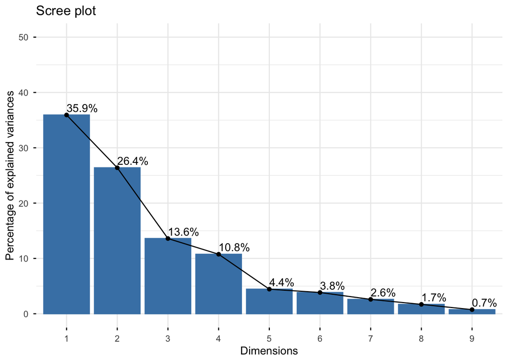

Le nombre d’axes pertinents dans l’ACP est déterminé en examinant les valeurs propres et le scree plot :

Selon le critère de Kaiser (valeur propre > 1) les trois premières composantes ont une valeur propre supérieure à 1, tandis que les autres ont des valeurs propres inférieures à 1, les rendant non pertinentes.

Donc les trois premières composantes sont pertinentes et expliquent une part importante de la variance, donc 3 axes.

## 5) Interpréter les axes retenus par rapport aux « Yaourts » et aux « Goûts ».

Les trois premières composantes expliquent une part importante de la variance et capturent les relations clés entre le goût des yaourts et les autres critères.

La deuxième composante (26.4%) : Elle est liée à l’aspect et au prix, distinguant les marques premium des plus économiques.

La troisième composante (13.6%) : Elle capture des relations subtiles entre goût, aspect et prix, révélant des différences de perception entre les clients.

## 6) Tracer le cercle des corrélations. Que peut-on dire du prix d’une part, du goût et de l’aspect d’autre part pour chaque yaourt ? Quelles sont les variables les mieux représentées sur le cercle 1x2 ?

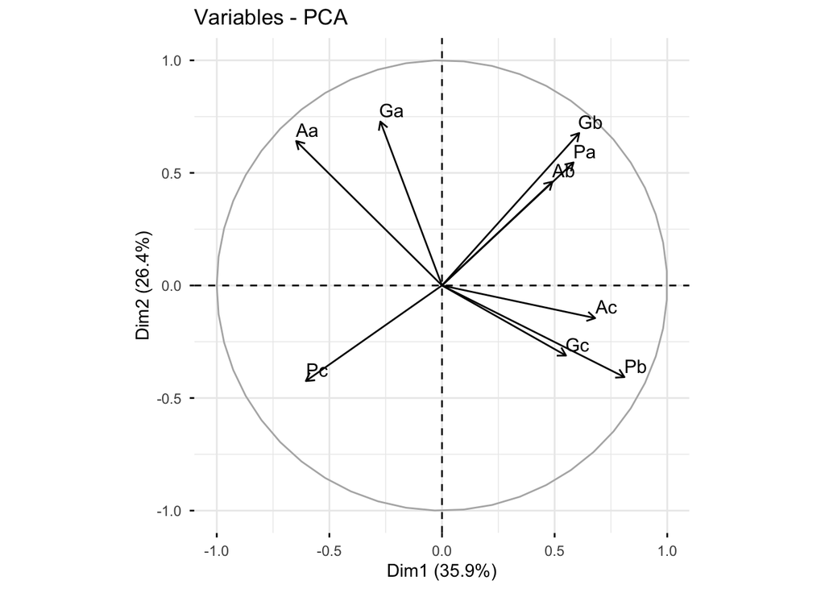

## 7) Peut-on trouver des axes principaux parmi les cinq premiers permettant de distinguer certains clients des autres ? cette distinction peut-elle s’expliquer à l’aide des données ?

Oui, on peut trouver des axes principaux parmi les cinq premiers qui permettent de distinguer certains clients des autres. En examinant les scores des clients sur ces axes, on peut observer des groupes de clients ayant des préférences similaires concernant le goût, l’aspect et le prix des yaourts. Les axes 1 et 2, qui expliquent une grande partie de la variance, montrent des distinctions importantes entre les clients en fonction de ces critères.

## 8) Quels sont les clients mal représentés par leur projection sur le plan principal 1x2 ? (on choisira une règle de décision que l’on expliquera). Y a-t-il beaucoup de clients mal représentés par leur projection sur les deux premiers axes ?

```
##  1  2  6 15 18 23
##  1  2  6 15 18 23
```

```
## [1] "Dim.1" "Dim.2"
```

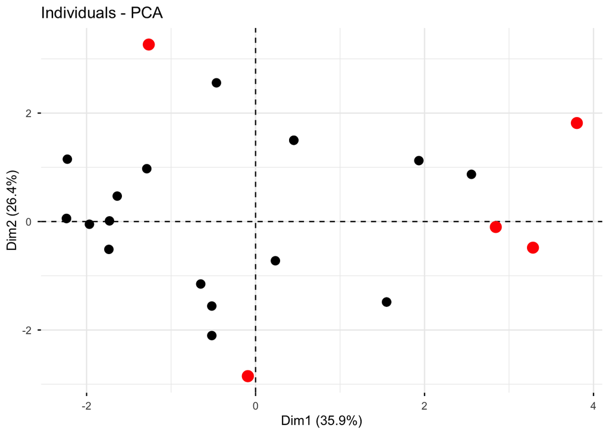

Les clients en rouge sont ceux qui ont une contribution élevée à la variance sur les deux premiers axes mais qui s’éloignent de la majorité des clients. Ces clients peuvent avoir des évaluations de yaourts différentes ou atypiques, ce qui les rend moins représentés par ces deux axes principaux.

## 9) Expliquer les points communs entre les clients 1, 2, 18, 20. En déduire le yaourt qui les satisfait le mieux. Que peut-on dire du groupe 3, 6, 13, 17 ?

```r
clients <- c(1, 2, 18, 20)
data_group1 <- data_yaourt[clients, c("Ga", "Gb", "Gc", "Aa", "Ab", "Ac", "Pa", "Pb", "Pc")]
data_group1
```

```
##    Ga Gb Gc Aa Ab Ac Pa Pb Pc
## 1   4  5  4  2  5  4  4  5  2
## 2   2  3  4  2  2  5  4  5  1
## 18  3  4  3  1  2  4  3  5  1
## 20  2  3  4  3  4  3  4  4  1
```

Analyse des points communs :

Prix : Les clients 1, 2, et 20 semblent plus sensibles au prix b (note de 4 ou 5).

```r
clients_group2 <- c(3, 6, 13, 17)
data_group2 <- data_yaourt[clients_group2, c("Ga", "Gb", "Gc", "Aa", "Ab", "Ac", "Pa", "Pb", "Pc")]
data_group2
```

```
##    Ga Gb Gc Aa Ab Ac Pa Pb Pc
## 3   2  2  3  2  3  1  1  3  4
## 6   1  1  3  1  2  2  1  4  4
## 13  1  2  3  2  3  1  1  3  4
## 17  2  1  3  2  2  2  1  4  4
```

Analyse des points communs :

Goût : Le groupe 2 semble avoir une préférence pour Goût c, avec des évaluations relativement élevées pour cette catégorie (3).

Aspect : L’aspect semble être jugé de manière modérée dans l’ensemble (principalement des notes autour de 2 et 3).

Le yaourt c semble être préféré par ce groupe, avec des évaluations relativement plus élevées pour le goût c. Les clients de ce groupe semblent aussi moins sensibles à l’aspect et plus sensibles au prix (préférant un prix plus bas).

## 10) Rédiger une note de synthèse de cette enquête pour le directeur de l’hypermarché.

Contexte de l’enquête :

L’enquête a été menée auprès de 25 clients afin d’évaluer leurs préférences sur trois marques de yaourts nature, appelées a, b, et c. Les clients ont attribué une note à chaque marque sur trois critères : le goût, l’aspect et le prix. Cette analyse en composantes principales (ACP) nous permet d’identifier les principales tendances parmi les clients et de recommander une stratégie commerciale visant à satisfaire le plus grand nombre de clients.

Goût : Le goût est un critère déterminant pour les clients, avec une préférence marquée pour le yaourt b (Goût b) parmi certains groupes de clients. Ce critère est particulièrement important pour les clients qui cherchent des produits de qualité supérieure, comme ceux de Goût a et Goût b, bien notés pour leur qualité gustative.

Aspect : L’aspect visuel des yaourts joue également un rôle clé dans les préférences des clients, bien que son influence soit moins forte que le goût. Les clients ont tendance à préférer un aspect soigné et attirant (notamment le yaourt b), mais cette préférence est moins marquée que pour le goût.

Prix : Le critère du prix montre des différences importantes entre les segments de clients. Certains clients privilégient des yaourts plus économiques (Prix c), tandis que d’autres sont prêts à payer plus pour un produit premium (Prix b). Le yaourt b semble être bien perçu pour son rapport qualité-prix.

2. Segmentation des clients :

L’analyse des groupes de clients permet de distinguer deux profils principaux parmi les consommateurs :

Groupe 2 (Clients 3, 6, 13, 17) : Ce groupe semble privilégier le yaourt c, notamment pour son goût (Goût c) tout en étant moins sensible à l’aspect et au prix. Ils semblent plus intéressés par des produits à prix abordable tout en restant satisfaits du goût.

3. Recommandations stratégiques :

Promotion ciblée : Le yaourt c, bien qu’il soit préféré par un groupe plus restreint, peut être promu en tant que produit économique, notamment dans des offres spéciales et réductions sur le prix pour attirer les clients sensibles aux prix.

Amélioration de l’aspect visuel : Un travail supplémentaire sur l’aspect visuel des yaourts (notamment pour le yaourt a) pourrait améliorer l’attrait de ce produit. Les clients qui préfèrent un aspect esthétique plus marqué pourraient être plus enclins à choisir des produits au packaging plus attrayant.

Rapport qualité-prix : Mettre en avant le rapport qualité-prix du yaourt b pourrait permettre de capter une large clientèle, tout en ajustant les prix pour répondre aux attentes des consommateurs plus sensibles au coût.

# Exercice 3 :

## Mise en œuvre de la Classification Ascendante Hiérarchique à l’aide des composantes de l’ACP.

On veut affiner les groupes obtenus de l’ACP. On effectue, à la suite de l’ACP normée, une Classification Ascendante Hiérarchique (CAH) sur les trois premières composantes de l’ACP.

## 1. Mettre en œuvre la CAH des étudiant-e-s à l’aide du critère de WARD et les trois premières composantes de l’ACP.

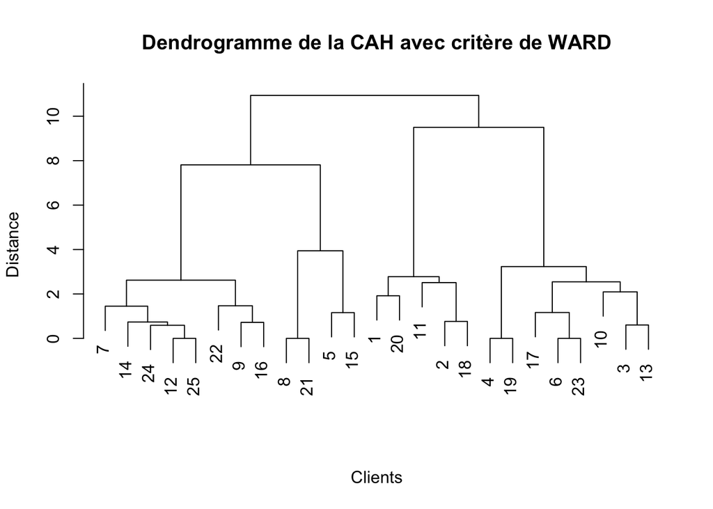

## 2. Faire une typologie en quatre groupes (coupure de l’arbre en quatre classes)

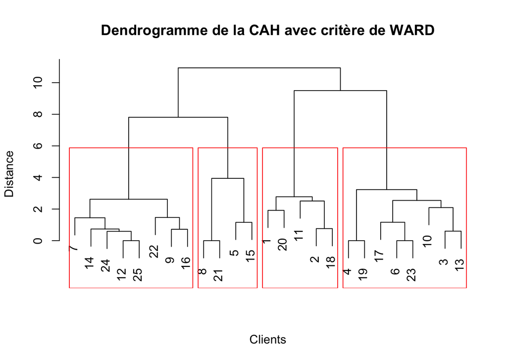

```
##  1  2  3  4  5  6  7  8  9 10 11 12 13 14 15 16 17 18 19 20 21 22 23 24 25
##  1  1  2  2  3  2  4  3  4  2  1  4  2  4  3  4  2  1  2  1  3  4  2  4  4
```

## 3. Décrire chacune des classes à l’aide des variables actives.

Moyennes des variables par groupe

| Group | Ga | Gb | Gc | Aa | Ab | Ac | Pa | Pb | Pc |
| --- | --- | --- | --- | --- | --- | --- | --- | --- | --- |
| 1 | 3.000 | 4.0 | 3.800 | 2.0 | 3.200 | 4.000 | 3.800 | 4.400 | 1.800 |
| 2 | 1.375 | 1.5 | 3.125 | 1.5 | 2.375 | 2.125 | 1.750 | 3.375 | 3.375 |
| 3 | 3.000 | 3.5 | 1.250 | 3.5 | 3.500 | 1.000 | 3.250 | 2.000 | 1.500 |
| 4 | 3.500 | 1.5 | 2.375 | 4.0 | 2.000 | 2.000 | 1.625 | 1.625 | 3.500 |

**Groupe 1 :**

Goût : Préférence pour Goût b.

Aspect : Préférence pour l’aspect c.

Prix : Sensibilité aux prix modérés à élevés.

**Groupe 2 :**

Goût : Préférence pour Goût c.

Aspect : Aspects relativement peu appréciés.

Prix : Recherche des produits à prix bas.

**Groupe 3 :**

Goût : Préférence pour Goût a et b.

Aspect : Préférence pour les aspects a et b.

Prix : Préférence pour des prix modérés à bas.

**Groupe 4 :**

Aspect : Préférence pour l’aspect a.

Prix : Forte préférence pour des prix bas.

Chaque groupe montre des préférences distinctes en termes de goût, aspect, et prix, permettant ainsi de mieux comprendre les segments de clients.

## 4. Représenter graphiquement l’histogramme valeurs moyennes des variables dans la classe et dans l’échantillon et donner une première tendance de la typologie de chaque classe.

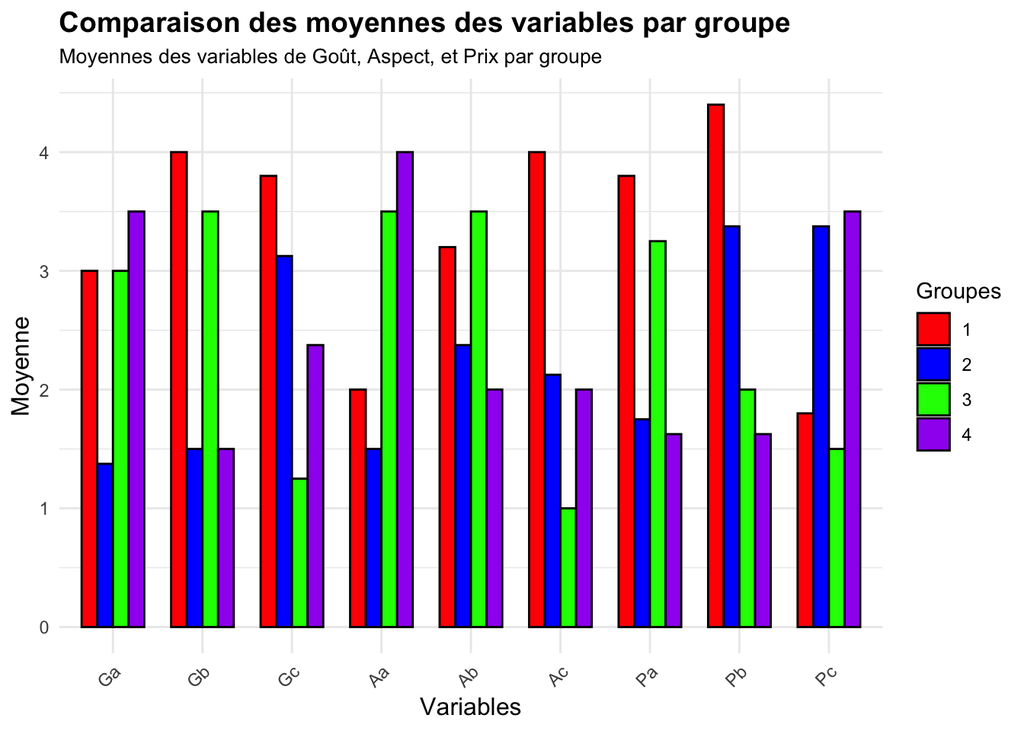

**Groupes 1 et 4 :**

**Groupe 2 :**

Cela pourrait suggérer que les clients du groupe 2 recherchent des yaourts moins chers, mais également de qualité inférieure en termes de goût.

**Groupe 3 :**

Cependant, le goût semble moins important dans ce groupe comparé aux autres groupes.

**Première tendance de la typologie de chaque classe :**

Groupe 1 : Clients qui préfèrent des yaourts au goût prononcé, avec une disposition à payer plus cher.

Groupe 2 : Clients qui cherchent des yaourts à bas prix, avec un goût perçu comme moins agréable.

Groupe 3 : Clients qui privilégient l’aspect visuel des yaourts plus que le goût ou le prix.

Groupe 4 : Clients qui semblent être partagés en termes de goût et d’aspect, mais avec une préférence pour les prix plus bas.

Cette typologie peut être utilisée pour ajuster les stratégies de marketing, en visant les groupes en fonction de leurs préférences spécifiques pour le goût, l’aspect et le prix des yaourts.

## 5. En déduire les variables les plus significatives par classe en utilisation le tableau des valeurs tests et des Probabilité associées (P_valeur).

P-valeurs des variables et leur significativité

| Variable | P_value | Significance |
| --- | --- | --- |
| Ga | 0.0430792 | Significatif |
| Gb | 0.0202707 | Significatif |
| Gc | 0.0060751 | Significatif |
| Aa | 0.0000026 | Significatif |
| Ab | 0.0971622 | Non significatif |
| Ac | 0.0036213 | Significatif |
| Pa | 0.0265577 | Significatif |
| Pb | 0.0000002 | Significatif |
| Pc | 0.1032938 | Non significatif |

Les variables **Ga, Gb, Gc, Aa, Ac, Pa, et Pb** sont les plus significatives pour différencier les groupes de clients dans cette analyse. Ces variables peuvent être considérées comme les plus pertinentes pour la typologie des clients. Les variables Ab et Pc n’apportent pas de distinction significative entre les groupes et peuvent être considérées comme moins influentes dans cette analyse.

## 6. Représenter graphiquement sur le plan 1 & 2, la projection des clients

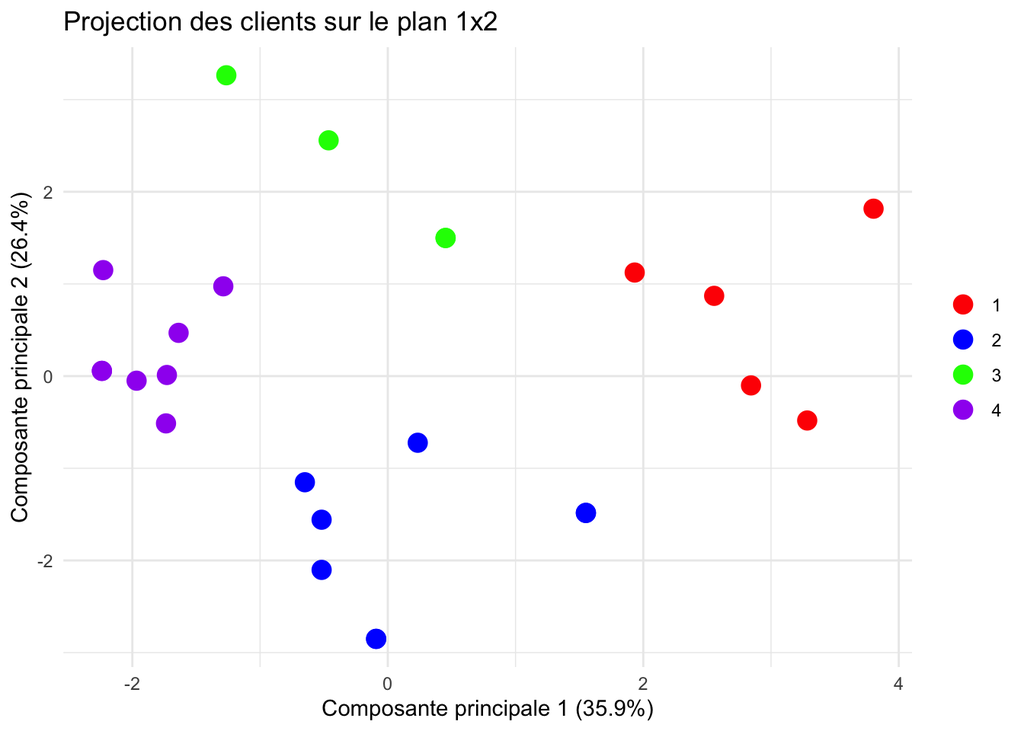

## 7. Dresser alors le tableau décrivant les quatre groupes et résumer en dix lignes les grandes tendances de chacun des quatre groupes de clients?

Moyennes des variables par groupe

| Group | Ga | Gb | Gc | Aa | Ab | Ac | Pa | Pb | Pc |
| --- | --- | --- | --- | --- | --- | --- | --- | --- | --- |
| 1 | 3.000 | 4.0 | 3.800 | 2.0 | 3.200 | 4.000 | 3.800 | 4.400 | 1.800 |
| 2 | 1.375 | 1.5 | 3.125 | 1.5 | 2.375 | 2.125 | 1.750 | 3.375 | 3.375 |
| 3 | 3.000 | 3.5 | 1.250 | 3.5 | 3.500 | 1.000 | 3.250 | 2.000 | 1.500 |
| 4 | 3.500 | 1.5 | 2.375 | 4.0 | 2.000 | 2.000 | 1.625 | 1.625 | 3.500 |

**Groupe 1 (Rouge)** : Ces clients préfèrent un goût prononcé et des yaourts plutôt chers, avec une forte appréciation pour les variables de goût et d’aspect. Ils privilégient les produits haut de gamme, notamment en termes de goût et de prix.

**Groupe 2 (Bleu)** : Ce groupe a une préférence pour les yaourts moins chers, avec un goût plus doux et une importance modérée de l’aspect. Ils semblent rechercher un bon rapport qualité/prix.

**Groupe 3 (Vert)** : Les clients de ce groupe montrent une préférence pour un goût modéré et un aspect plus simple. Ils valorisent un bon rapport qualité/prix, avec une tendance à choisir des produits plus abordables.

**Groupe 4 (Violet)** : Les clients de ce groupe semblent être attirés par des yaourts au goût simple et abordables. Ils privilégient des produits à prix plus bas, avec un aspect moins marqué, ce qui reflète une recherche d’un bon rapport qualité/prix mais avec moins d’accent sur la complexité du goût